# Titanic Analysis

```r
library("ggplot2")
library("dplyr")
```

Steps involved in data analysis:

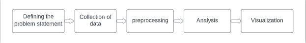

Picture of process

The process of data analysis would include all these steps for the given problem statement. Example: Analyze the products that are being rapidly sold out and details of frequent customers of a retail shop.

- Defining the problem statement – Understand the goal, and what is needed to be done. In this case, our problem statement is – “The product is mostly sold out and list of customers who often visit the store.”
- Collection of data – Not all the company’s data is necessary, understand the relevant data according to the problem. Here the required columns are product ID, customer ID, and date visited.
- Preprocessing – Cleaning the data is mandatory to put it in a structured format before performing analysis.
  1. Removing outliers( noisy data).
  2. Removing null or irrelevant values in the columns. (Change null values to mean value of that column.)
  3. If there is any missing data, either ignore the tuple or fill it with a mean value of the column.

## Data Analysis using the Titanic dataset

Save the dataset in the current working directory, now we will start analysis (getting to know our data).

```r
titanic=read.csv("titanic.csv")
head(titanic)
```

|  | PassengerId | Survived | Pclass | Name | Sex | Age | SibSp | Parch | Ticket | Fare | Cabin | Embarked |
| --- | --- | --- | --- | --- | --- | --- | --- | --- | --- | --- | --- | --- |
| 1 | 892 | 0 | 3 | Kelly, Mr. James | male | 34.5 | 0 | 0 | 330911 | 7.8292 |  | Q |
| 2 | 893 | 1 | 3 | Wilkes, Mrs. James (Ellen Needs) | female | 47.0 | 1 | 0 | 363272 | 7.0000 |  | S |
| 3 | 894 | 0 | 2 | Myles, Mr. Thomas Francis | male | 62.0 | 0 | 0 | 240276 | 9.6875 |  | Q |
| 4 | 895 | 0 | 3 | Wirz, Mr. Albert | male | 27.0 | 0 | 0 | 315154 | 8.6625 |  | S |
| 5 | 896 | 1 | 3 | Hirvonen, Mrs. Alexander (Helga E Lindqvist) | female | 22.0 | 1 | 1 | 3101298 | 12.2875 |  | S |
| 6 | 897 | 0 | 3 | Svensson, Mr. Johan Cervin | male | 14.0 | 0 | 0 | 7538 | 9.2250 |  | S |

Our dataset contains all the columns like name, age, gender of the passenger and class they have traveled in, whether they have survived or not, etc. To understand the class(data type) of each column sapply() method can be used.

```r
summary(titanic)
```

```
##   PassengerId        Survived          Pclass          Name
##  Min.   : 892.0   Min.   :0.0000   Min.   :1.000   Length:418
##  1st Qu.: 996.2   1st Qu.:0.0000   1st Qu.:1.000   Class :character
##  Median :1100.5   Median :0.0000   Median :3.000   Mode  :character
##  Mean   :1100.5   Mean   :0.3636   Mean   :2.266
##  3rd Qu.:1204.8   3rd Qu.:1.0000   3rd Qu.:3.000
##  Max.   :1309.0   Max.   :1.0000   Max.   :3.000
##
##      Sex                 Age            SibSp            Parch
##  Length:418         Min.   : 0.17   Min.   :0.0000   Min.   :0.0000
##  Class :character   1st Qu.:21.00   1st Qu.:0.0000   1st Qu.:0.0000
##  Mode  :character   Median :27.00   Median :0.0000   Median :0.0000
##                     Mean   :30.27   Mean   :0.4474   Mean   :0.3923
##                     3rd Qu.:39.00   3rd Qu.:1.0000   3rd Qu.:0.0000
##                     Max.   :76.00   Max.   :8.0000   Max.   :9.0000
##                     NA's   :86
##     Ticket               Fare            Cabin             Embarked
##  Length:418         Min.   :  0.000   Length:418         Length:418
##  Class :character   1st Qu.:  7.896   Class :character   Class :character
##  Mode  :character   Median : 14.454   Mode  :character   Mode  :character
##                     Mean   : 35.627
##                     3rd Qu.: 31.500
##                     Max.   :512.329
##                     NA's   :1
```

```r
sapply(titanic, class)
```

```
## PassengerId    Survived      Pclass        Name         Sex         Age
##   "integer"   "integer"   "integer" "character" "character"   "numeric"
##       SibSp       Parch      Ticket        Fare       Cabin    Embarked
##   "integer"   "integer" "character"   "numeric" "character" "character"
```

```r
titanic$Survived=as.factor(titanic$Survived)
titanic$Sex=as.factor(titanic$Sex)
sapply(titanic, class)
```

```
## PassengerId    Survived      Pclass        Name         Sex         Age
##   "integer"    "factor"   "integer" "character"    "factor"   "numeric"
##       SibSp       Parch      Ticket        Fare       Cabin    Embarked
##   "integer"   "integer" "character"   "numeric" "character" "character"
```

Dealing with missing values:

```r
sum(is.na(titanic))
```

```
## [1] 87
```

```r
dropnull_titanic = titanic[rowSums(is.na(titanic))<=0,]

survivedlist = dropnull_titanic[dropnull_titanic$Survived == 1,]
notsurvivedlist = dropnull_titanic[dropnull_titanic$Survived == 0,]
```

Visualize the rate of survived people:

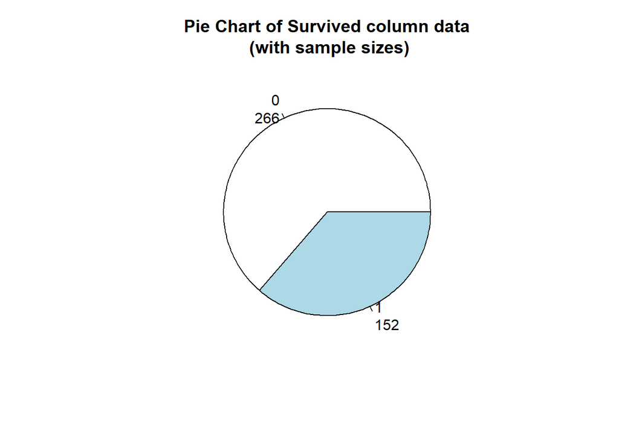

```r
mytable <- table(titanic$Survived)
lbls <- paste(names(mytable), "\n", mytable, sep="")
pie(mytable,
    labels = lbls,
    main="Pie Chart of Survived column data\n (with sample sizes)")
```

Learning more of the groups of the survived:

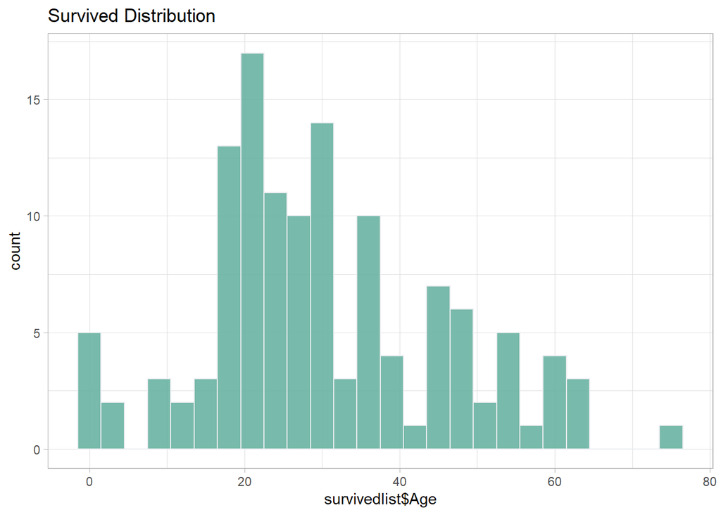

```r
survivedlist %>% ggplot(aes(survivedlist$Age))+
  geom_histogram(binwidth=3, fill="#69b3a2", color="#e9ecef", alpha=0.9)+
  labs(
    xlab="gender",
    ylab="frequency",
    )+
  ggtitle("Survived Distribution")+
  theme_light()
```

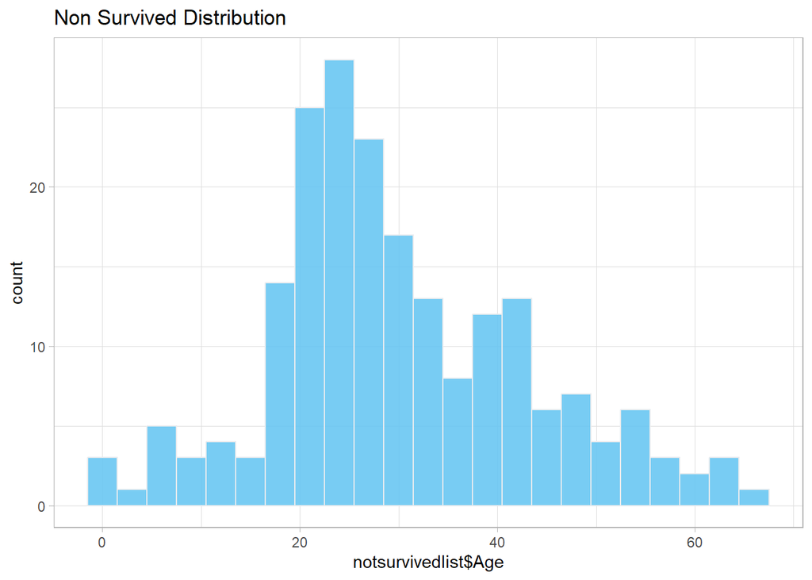

```r
notsurvivedlist %>% ggplot(aes(notsurvivedlist$Age))+
  geom_histogram(binwidth=3, fill="#69c6f2", color="#e9ecef", alpha=0.9)+
  labs(
    xlab="gender",
    ylab="frequency",
    )+
  ggtitle("Non Survived Distribution")+
  theme_light()
```

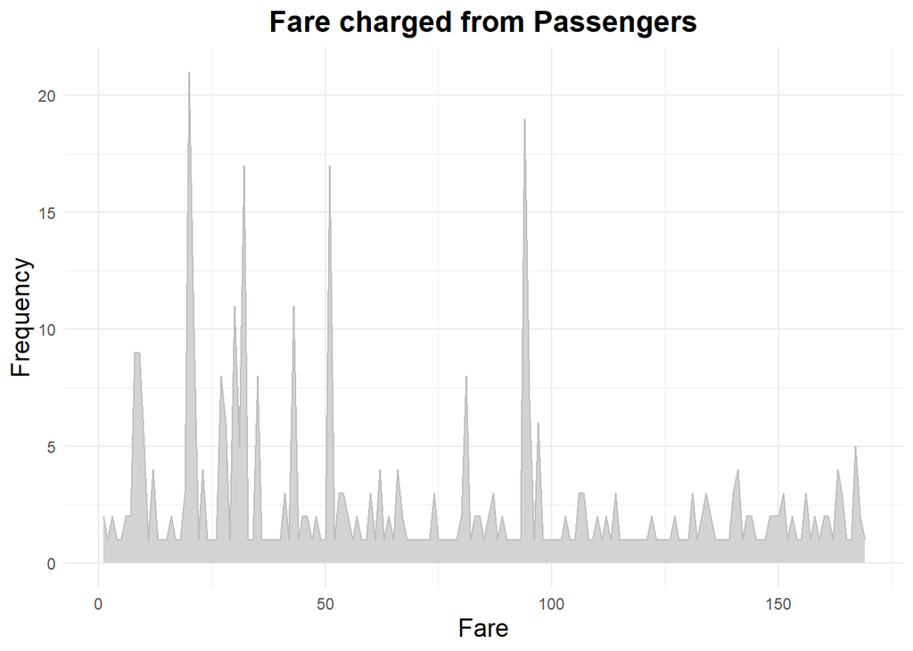

```r
fare_data <- as.data.frame(table(titanic$Fare))
colnames(fare_data) <- c("Fare", "Frequency")

fare_density <- ggplot(fare_data, aes(x = as.numeric(Fare), y = Frequency)) +
  geom_area(stat = "identity", fill = "lightgray", color = "gray") +
  labs(title = "Fare charged from Passengers", x = "Fare", y = "Frequency") +
  theme_minimal() +
  theme(plot.title = element_text(hjust = 0.5, size = 16, face = "bold"),
        axis.title = element_text(size = 14))


# Boxplot
fare_boxplot <- ggplot(titanic, aes(y = Fare)) +
  geom_boxplot(fill = "lightblue", color = "darkblue", outlier.colour = "red") +
  labs(title = "Fare charged from Passengers", y = "Fare") +
  theme_minimal()

fare_density
```

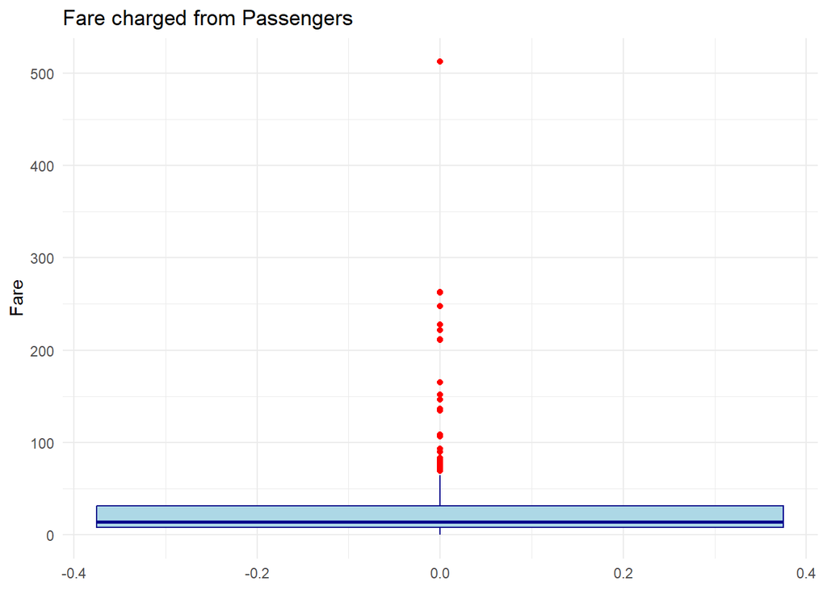

```r
fare_boxplot
```

## Clustering

#### Idea

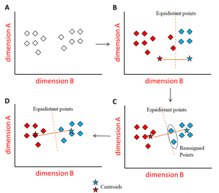

Kmeans

Unsupervised Machine Learning is the process of teaching a computer to use unlabeled, unclassified data and enabling the algorithm to operate on that data without supervision. Without any previous data training, the machine’s job in this case is to organize unsorted data according to parallels, patterns, and variations.

K means clustering, assigns data points to one of the K clusters depending on their distance from the center of the clusters. It starts by randomly assigning the clusters centroid in the space. Then each data point assign to one of the cluster based on its distance from centroid of the cluster. After assigning each point to one of the cluster, new cluster centroids are assigned. This process runs iteratively until it finds good cluster. In the analysis we assume that number of cluster is given in advanced and we have to put points in one of the group.